# Comparing algorithms for the iris dataset

Salma Elshahawy

8/31/2020

# 1. Prepare Problem

# a) Load libraries

```r
library(caret)
```

```r
library(ggplot2)
library(dplyr)
```

# b) Load dataset

```r
data("iris")
dataset <- iris
```

# c) Split-out validation dataset

```r
# create a list of 80% of the rows in the original dataset we can use for training
validationIndex <- createDataPartition(dataset$Species, p=0.80, list=FALSE)
# select 20% of the data for validation
validation <- dataset[-validationIndex,]
# use the remaining 80% of data to training and testing the models
dataset <- dataset[validationIndex,]
```

# 2. Summarize Data

# a) Descriptive statistics

```r
dim(dataset)
```

```
## [1] 120   5
```

```r
sapply(dataset, class)
```

```
## Sepal.Length  Sepal.Width Petal.Length  Petal.Width      Species
##    "numeric"    "numeric"    "numeric"    "numeric"     "factor"
```

```r
## Peek the data
head(dataset)
```

```
##   Sepal.Length Sepal.Width Petal.Length Petal.Width Species
## 1          5.1         3.5          1.4         0.2  setosa
## 2          4.9         3.0          1.4         0.2  setosa
## 3          4.7         3.2          1.3         0.2  setosa
## 4          4.6         3.1          1.5         0.2  setosa
## 5          5.0         3.6          1.4         0.2  setosa
## 6          5.4         3.9          1.7         0.4  setosa
```

```r
# list the levels class
levels(dataset$Species)
```

```
## [1] "setosa"     "versicolor" "virginica"
```

```r
# summarize the class distribution
percentage <- prop.table(table(dataset$Species)) * 100
cbind(freq=table(dataset$Species), percentage=percentage)
```

```
##            freq percentage
## setosa       40   33.33333
## versicolor   40   33.33333
## virginica    40   33.33333
```

```r
# summarize attribute distributions
summary(dataset)
```

```
##   Sepal.Length    Sepal.Width     Petal.Length    Petal.Width
##  Min.   :4.300   Min.   :2.200   Min.   :1.000   Min.   :0.100
##  1st Qu.:5.100   1st Qu.:2.800   1st Qu.:1.500   1st Qu.:0.300
##  Median :5.800   Median :3.000   Median :4.400   Median :1.300
##  Mean   :5.848   Mean   :3.067   Mean   :3.768   Mean   :1.211
##  3rd Qu.:6.400   3rd Qu.:3.325   3rd Qu.:5.100   3rd Qu.:1.825
##  Max.   :7.700   Max.   :4.200   Max.   :6.900   Max.   :2.500
##        Species
##  setosa    :40
##  versicolor:40
##  virginica :40
##
##
##
```

# b) Data visualizations

```r
# Univaraite plots
# split input and output
x <- dataset[,1:4]
y <- dataset[,5]
```

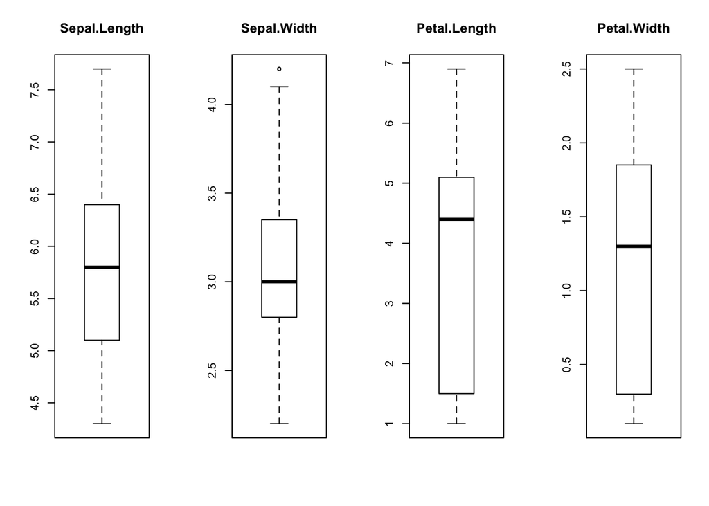

```r
# boxplot for each attribute on one image
par(mfrow=c(1,4))
for(i in 1:4) {
  boxplot(x[,i], main=names(iris)[i])
}
```

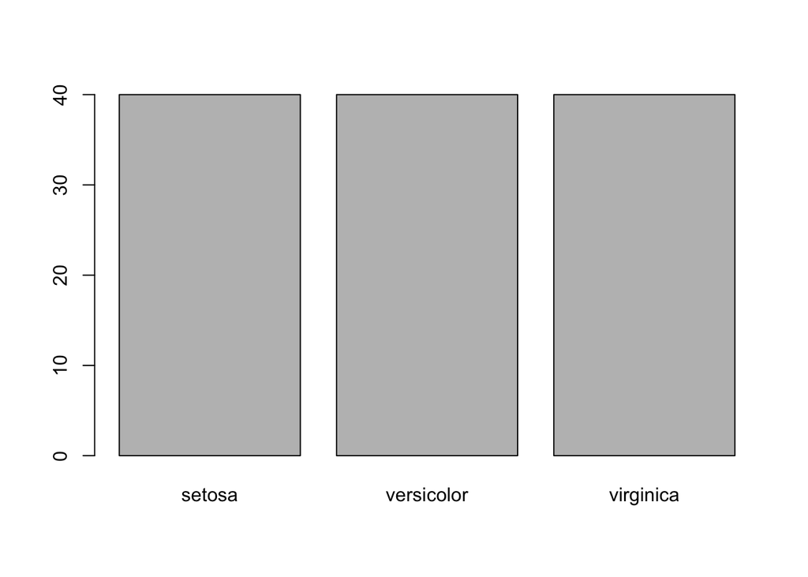

```r
# barplot for class breakdown
plot(y)
```

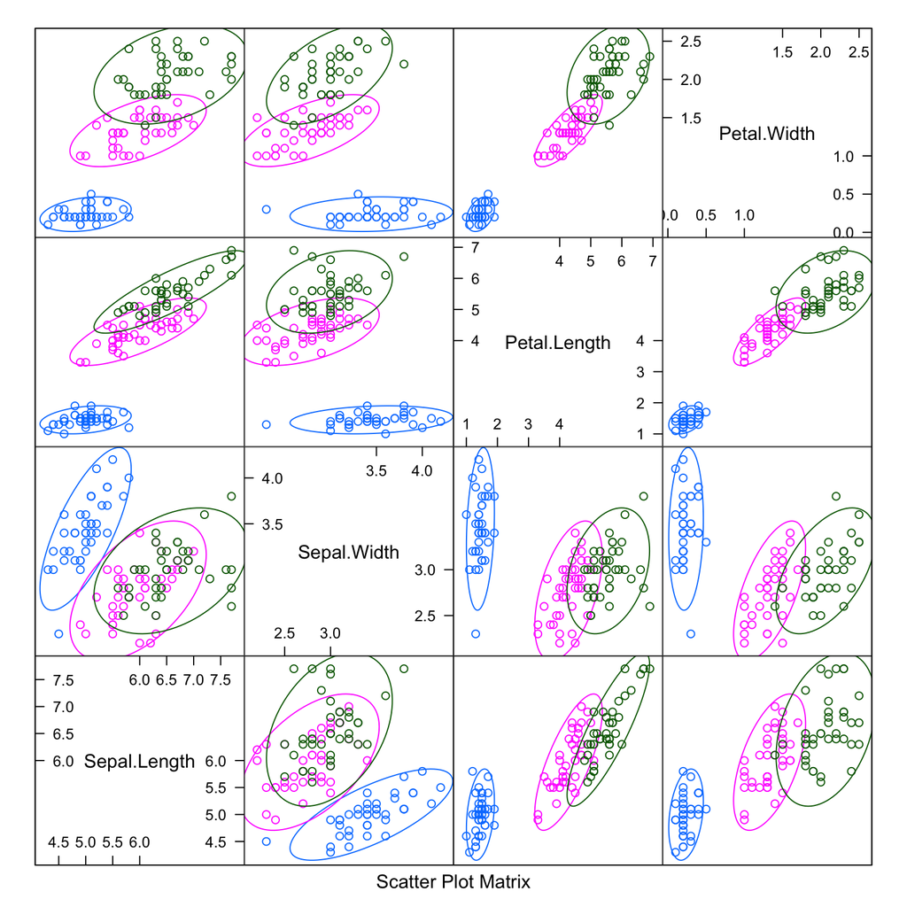

```r
# multivariate plot
# scatterplot matrix
featurePlot(x=x, y=y, plot="ellipse")
```

We can see some clear relationships between the input attributes (trends) and between attributes and the class values

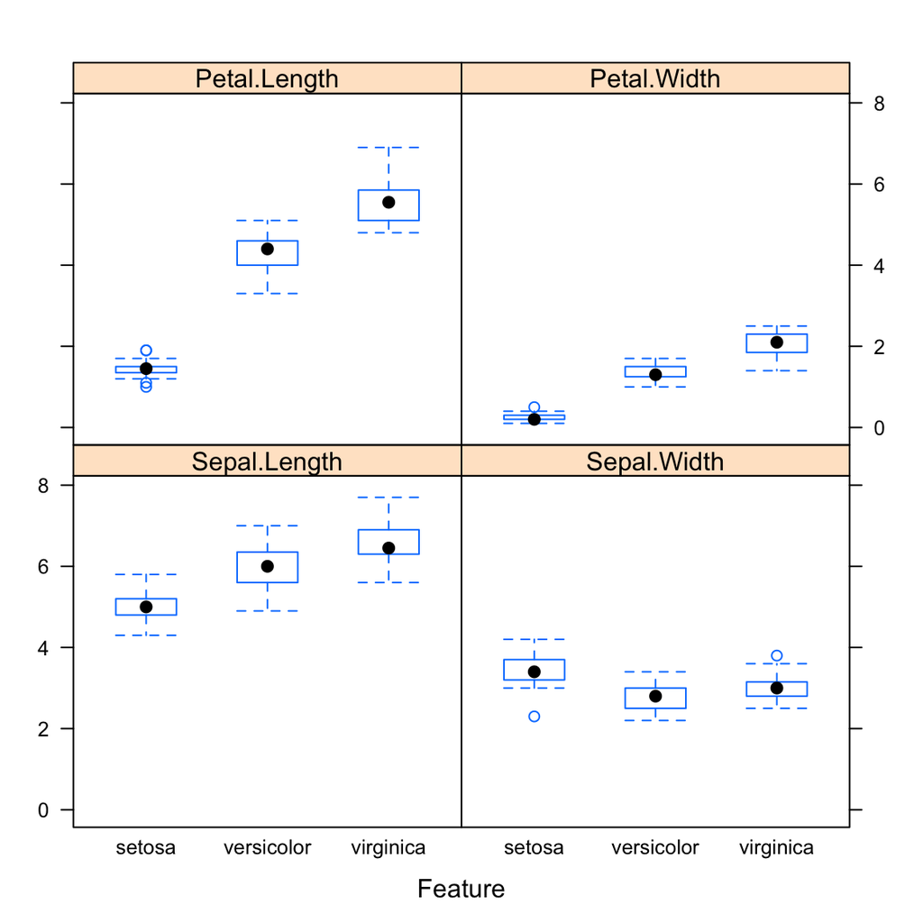

```r
# box and whisker plots for each attribute
featurePlot(x=x, y=y, plot="box")
```

This is useful as it shows that there are clearly different distributions of the attributes for each class value. Next we can get an idea of the distribution of each attribute, again like the box and whisker plots, broken down by class value. Sometimes histograms are good for this, but in this case we will use some probability density plots to give nice smooth lines for each distribution.

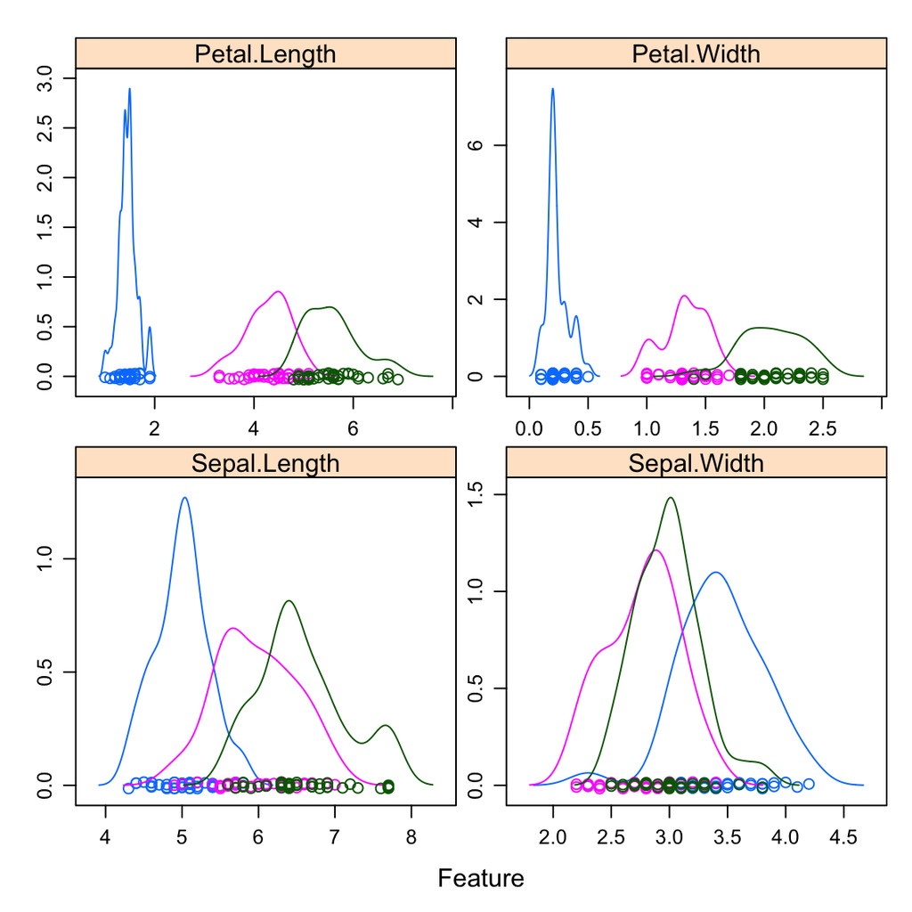

```r
# density plots for each attribute by class value
scales <- list(x=list(relation="free"), y=list(relation="free"))
featurePlot(x=x, y=y, plot="density", scales=scales)
```

Like the boxplots, we can see the difference in distribution of each attribute by class value. We can also see the Gaussian-like distribution (bell curve) of each attribute.